# Predicting Revenue from Search Engine Advertising Data

MATH2319 - Machine Learning Course Project

Ben Cole - s3412349

Print Date: 13/06/2019

# 1 **Phase 1 - Introduction, Cleaning, and Exploration**

## 1.1 Outline

The prescribed data set contained advertising metrics provided by a prominent search engine. The data contained several descriptive features pertaining to a range of information. Finally, the target feature was a measure of revenue associated with each of the observations.  
The dataset was used to create a supervised machine learning model to predict values for the target feature. Phase 1 of this report contains the introduction, cleaning, and exploration of the dataset. Phase 2 contains the creation, training, and deployment of the machine learning algorithm.

### 1.1.1 Nature of the Data

The below is an exerpt from accompanying documentation about the dataset.

Features in this data set are as follows:

- companyId: Company ID of record (categorical)
- countryId: Country ID of record (categorical)
- deviceType: Device type of record (categorical corresponding to desktop, mobile, tablet)
- day: Day of record (integer between 1 (oldest) and 30 for train, 31 and 35 (most recent) for test)
- dow: Day of week of the record (categorical)
- price1, price2, price3: Price combination for the record set by the company (numeric)
- ad_area: area of advertisement (numeric)
- ad_ratio: ratio of advertisement’s length to its width (numeric)
- requests, impression, cpc, ctr, viewability: Various metrics related to the record (numeric)
- ratio1, …, ratio5: Ratio characteristics related to the record (numeric)
- y (target feature): revenue-related metric (numeric)

#### 1.1.1.1 Target Feature

The column/variable **y** was selected as the target feature in the dataset.

#### 1.1.1.2 Descriptive Features

All other columns/variables in the dataset, as outlined above, were chosen as descriptive features.

## 1.2 Data Processing

### 1.2.1 Libraries

The following libraries were used in the below data processing and exploration.

```r
library(pacman)                         ## for loading multiple packages
suppressMessages(p_load(character.only = T,
                        install = T,
                        c("tidyverse",  ## thanks Hadley
                          "lubridate",  ## for handling dates
                          "forcats",    ## for categorial variables, not for felines
                          "zoo",        ## some data cleaning capabilities
                          "lemon",      ## add ons for ggplot
                          "rvest",      ## scraping web pages
                          "knitr",      ## knitting to RMarkdown
                          "kableExtra", ## add ons for knitr tables
                          "scales",     ## quick and easy formatting prettynums
                          "grid",       ## for stacking ggplots
                          "gridExtra",  ## also for stacking ggplots
                          "e1071",      ## for skew and kurtosis
                          "janitor",    ## cleaning colnames
                          "beepr",      ## plays a beep tone
                          "mlr",
                          "FSelector")))
```

### 1.2.2 Loading Data

The prescribed data was made available in comma separated value file format.

```r
advertising_train <- read_csv("advertising_train.csv")
sample_adv <- sample_n(advertising_train, 20)
kable_styling(kable(sample_adv[ , 1:(ncol(sample_adv)/2)],
                    caption = "Sample of Advertising Data Frame"),
              font_size = 10, bootstrap_options = c("striped"),
              full_width = F)
```

Sample of Advertising Data Frame

| case_id | companyId | countryId | deviceType | day | dow | price1 | price2 | price3 | ad_area | ad_ratio |
| --- | --- | --- | --- | --- | --- | --- | --- | --- | --- | --- |
| 89137 | 43 | 57 | 1 | 14 | Friday | 0.16 | 0.53 | 1.0528 | 1.6000 | 0.15625 |
| 154313 | 40 | 70 | 1 | 22 | Saturday | 0.10 | 0.10 | 0.2000 | 0.0001 | 1.00000 |
| 10802 | 43 | 191 | 2 | 3 | Monday | 3.42 | 3.42 | 3.4210 | 0.0001 | 1.00000 |
| 173697 | 43 | 50 | 1 | 25 | Tuesday | 0.28 | 0.57 | 1.1232 | 7.5000 | 0.83333 |
| 185721 | 159 | 98 | 2 | 26 | Wednesday | 0.00 | 0.00 | 0.0000 | 0.0001 | 1.00000 |
| 113962 | 95 | 234 | 3 | 17 | Monday | 4.52 | 8.17 | 12.2600 | 18.0000 | 2.00000 |
| 28534 | 159 | 166 | 1 | 5 | Wednesday | 0.17 | 0.33 | 0.6738 | 7.5000 | 0.83333 |
| 189306 | 40 | 56 | 1 | 27 | Thursday | 0.00 | 0.00 | 0.0000 | 0.0001 | 1.00000 |
| 10629 | 159 | 98 | 3 | 3 | Monday | 0.00 | 0.00 | 0.0000 | 0.0001 | 1.00000 |
| 163664 | 159 | 57 | 2 | 23 | Sunday | 0.70 | 1.30 | 2.6207 | 24.2500 | 0.25773 |
| 11597 | 43 | 107 | 2 | 3 | Monday | 0.00 | 0.00 | 0.0000 | 0.0001 | 1.00000 |
| 41168 | 43 | 234 | 2 | 7 | Friday | 0.52 | 1.46 | 2.9174 | 7.5000 | 0.83333 |
| 103257 | 95 | 38 | 3 | 16 | Sunday | 0.01 | 0.12 | 0.3500 | 7.5000 | 0.83333 |
| 114929 | 43 | 234 | 5 | 17 | Monday | 0.00 | 0.00 | 0.0000 | 0.0001 | 1.00000 |
| 208002 | 43 | 65 | 2 | 30 | Sunday | 0.00 | 0.00 | 0.0000 | 7.5000 | 0.83333 |
| 28589 | 157 | 234 | 2 | 5 | Wednesday | 0.35 | 0.55 | 0.5500 | 7.5000 | 0.83333 |
| 70088 | 43 | 218 | 2 | 11 | Tuesday | 0.00 | 0.00 | 0.0000 | 0.0001 | 1.00000 |
| 8372 | 43 | 234 | 2 | 2 | Sunday | 3.42 | 3.42 | 3.4210 | 0.0001 | 1.00000 |
| 207909 | 43 | 218 | 1 | 30 | Sunday | 0.50 | 0.77 | 1.5282 | 9.4080 | 0.83333 |
| 182377 | 159 | 167 | 1 | 26 | Wednesday | 0.00 | 0.00 | 0.0000 | 0.0001 | 1.00000 |

```r
kable_styling(kable(sample_adv[ , c(1, ((ncol(sample_adv)/2)+1):ncol(sample_adv))],
                    caption = "Sample of Advertising Data Frame (cont)"),
              font_size = 10, bootstrap_options = c("striped"),
              full_width = F)
```

Sample of Advertising Data Frame (cont)

| case_id | requests | impression | cpc | ctr | viewability | ratio1 | ratio2 | ratio3 | ratio4 | ratio5 | y |
| --- | --- | --- | --- | --- | --- | --- | --- | --- | --- | --- | --- |
| 89137 | 4014 | 1568 | 0.5185 | 0.0006 | 0.5571 | 0.2997 | 0.9636 | 0.0593 | 0.1467 | 0.7940 | 0.1129179 |
| 154313 | 1770 | 1590 | 0.1144 | 0.0013 | 0.3056 | 0.9912 | 0.9509 | 0.1308 | 0.4252 | 0.4440 | 0.1256970 |
| 10802 | 77781 | 5144 | 0.9463 | 0.0089 | 0.9340 | 0.9821 | 0.0039 | 1.0002 | 0.0000 | 0.0000 | 0.5897182 |
| 173697 | 1765 | 605 | 0.1810 | 0.0017 | 0.5173 | 0.4893 | 0.8050 | 0.0661 | 0.2116 | 0.7223 | 0.1793608 |
| 185721 | 401121 | 280490 | 0.1205 | 0.0005 | 0.1970 | 1.0000 | 0.9975 | 1.0003 | 0.0000 | 0.0000 | 0.0232646 |
| 113962 | 1381 | 624 | 2.7657 | 0.0016 | 0.3381 | 0.5192 | 0.9327 | 0.0048 | 0.7179 | 0.2772 | 1.6999474 |
| 28534 | 0 | 0 | 0.0000 | 0.0000 | 0.0000 | 0.0000 | 0.0000 | 0.0000 | 0.0000 | 0.0000 | 0.3597008 |
| 189306 | 2888 | 2744 | 0.0623 | 0.0004 | 0.6051 | 1.0000 | 0.9315 | 0.0977 | 0.4468 | 0.4555 | 0.0195315 |
| 10629 | 0 | 0 | 0.0000 | 0.0000 | 0.0000 | 0.0000 | 0.0000 | 0.0000 | 0.0000 | 0.0000 | 0.0100396 |
| 163664 | 644 | 610 | 1.4575 | 0.0016 | 0.8638 | 0.8443 | 0.8066 | 1.0000 | 0.0000 | 0.0000 | 1.9485175 |
| 11597 | 55 | 33 | 0.0028 | 0.2121 | 0.8889 | 1.0000 | 1.0000 | 1.0000 | 0.0000 | 0.0000 | 0.0440000 |
| 41168 | 501517 | 118649 | 2.4368 | 0.0006 | 0.6936 | 0.6696 | 0.5320 | 1.0001 | 0.0000 | 0.0000 | 0.4032057 |
| 103257 | 6819 | 6040 | 0.9572 | 0.0005 | 0.1482 | 0.9336 | 0.7132 | 0.0015 | 0.8747 | 0.1238 | 0.3663711 |
| 114929 | 316 | 310 | 0.1446 | 0.0129 | 0.9949 | 1.0000 | 0.8871 | 1.0000 | 0.0000 | 0.0000 | 1.7728421 |
| 208002 | 372 | 364 | 0.2177 | 0.0027 | 0.4877 | 1.0000 | 0.9918 | 1.0000 | 0.0000 | 0.0000 | 0.8599089 |
| 28589 | 6375 | 3138 | 3.2508 | 0.0016 | 0.6652 | 0.9605 | 0.2967 | 1.0000 | 0.0000 | 0.0000 | 2.5503668 |
| 70088 | 20 | 20 | 0.0009 | 0.2500 | 1.0000 | 1.0000 | 0.9500 | 1.0000 | 0.0000 | 0.0000 | 0.3636364 |
| 8372 | 12 | 4 | 0.0445 | 0.2500 | 1.0000 | 1.0000 | 0.7500 | 1.0000 | 0.0000 | 0.0000 | 7.2440000 |
| 207909 | 0 | 0 | 0.0000 | 0.0000 | 0.0000 | 0.0000 | 0.0000 | 0.0000 | 0.0000 | 0.0000 | 0.5389444 |
| 182377 | 0 | 0 | 0.0000 | 0.0000 | 0.0000 | 0.0000 | 0.0000 | 0.0000 | 0.0000 | 0.0000 | 0.4075758 |

### 1.2.3 Classifying Data

R and `dplyr` parse data files to guessed data types when loaded. Typically, columns with text are parsed as `character` type, columns with digits are parsed as `numeric`, and boolean columns are parsed as `logical`. Per the above feature definitions, the categorical data was re-classified as `factor`s.

```r
advertising_train$companyId <- as.factor(advertising_train$companyId)
advertising_train$countryId <- as.factor(advertising_train$countryId)
advertising_train$deviceType <- as.factor(advertising_train$deviceType)
advertising_train$dow <- as.factor(advertising_train$dow)
sapply(advertising_train, class)
```

```
##     case_id   companyId   countryId  deviceType         day         dow
##   "numeric"    "factor"    "factor"    "factor"   "numeric"    "factor"
##      price1      price2      price3     ad_area    ad_ratio    requests
##   "numeric"   "numeric"   "numeric"   "numeric"   "numeric"   "numeric"
##  impression         cpc         ctr viewability      ratio1      ratio2
##   "numeric"   "numeric"   "numeric"   "numeric"   "numeric"   "numeric"
##      ratio3      ratio4      ratio5           y
##   "numeric"   "numeric"   "numeric"   "numeric"
```

### 1.2.4 Descriptive Statistics

#### 1.2.4.1 Numeric Features

The below table outlines basic descriptive statistics about the centre and spread of the data for each of the numeric descriptive features, and numeric target feature. This table indicates that the numeric features each had distributions of different shapes and locations.

```r
advertising_train_long_num <- select(advertising_train,
                                     colnames(advertising_train),
                                     -case_id, -countryId,
                                     -companyId, -deviceType,
                                     -dow)

advertising_train_long_num <- gather(advertising_train_long_num,
                                     key = "Variable",
                                     value = "Value")

summary_adv_num <- summarise(group_by(advertising_train_long_num,
                                      Variable),
                             "Mean" = mean(Value, na.rm = T),
                             "Std Dev" = sd(Value, na.rm = T),
                             "Min" = min(Value, na.rm = T),
                             "Q1" = quantile(Value, 0.25, na.rm = T),
                             "Median" = median(Value, na.rm = T),
                             "Q3" = quantile(Value, 0.75, na.rm = T),
                             "Max" = max(Value, na.rm = T),
                             "Number of NA" = sum(is.na(Value)))

kable_styling(kable(summary_adv_num,
                    digits = 3, format.args = list(nsmall = 3,
                                                   scientific = F,
                                                   big.mark = ","),
                    caption = "Summary Statistics of Numeric Variables"),
              font_size = 10, bootstrap_options = c("striped"),
              full_width = F)
```

Summary Statistics of Numeric Variables

| Variable | Mean | Std Dev | Min | Q1 | Median | Q3 | Max | Number of NA |
| --- | --- | --- | --- | --- | --- | --- | --- | --- |
| ad_area | 4.724 | 6.273 | 0.000 | 0.000 | 0.000 | 7.500 | 36.000 | 0.000 |
| ad_ratio | 0.923 | 0.482 | 0.083 | 0.833 | 1.000 | 1.000 | 5.000 | 0.000 |
| cpc | 0.178 | 0.707 | 0.000 | 0.000 | 0.016 | 0.125 | 132.534 | 0.000 |
| ctr | 0.033 | 0.093 | 0.000 | 0.000 | 0.002 | 0.012 | 2.000 | 0.000 |
| day | 15.791 | 8.386 | 1.000 | 9.000 | 16.000 | 23.000 | 30.000 | 0.000 |
| impression | 5,585.714 | 98,713.340 | 0.000 | 0.000 | 99.000 | 1,058.000 | 6,100,324.000 | 0.000 |
| price1 | 0.438 | 1.281 | 0.000 | 0.000 | 0.010 | 0.190 | 14.690 | 0.000 |
| price2 | 0.630 | 1.482 | 0.000 | 0.000 | 0.090 | 0.570 | 63.120 | 0.000 |
| price3 | 0.932 | 1.840 | 0.000 | 0.000 | 0.295 | 0.986 | 78.900 | 0.000 |
| ratio1 | 0.558 | 0.447 | 0.000 | 0.000 | 0.750 | 1.000 | 1.000 | 0.000 |
| ratio2 | 0.491 | 0.414 | 0.000 | 0.000 | 0.627 | 0.896 | 1.027 | 0.000 |
| ratio3 | 0.312 | 0.444 | 0.000 | 0.000 | 0.028 | 1.000 | 1.500 | 0.000 |
| ratio4 | 0.131 | 0.240 | 0.000 | 0.000 | 0.000 | 0.164 | 1.077 | 0.000 |
| ratio5 | 0.188 | 0.297 | 0.000 | 0.000 | 0.000 | 0.385 | 1.200 | 0.000 |
| requests | 8,678.997 | 122,347.229 | 0.000 | 0.000 | 147.000 | 1,633.000 | 6,701,924.000 | 0.000 |
| viewability | 0.378 | 0.366 | 0.000 | 0.000 | 0.332 | 0.716 | 7.000 | 0.000 |
| y | 0.847 | 1.391 | 0.000 | 0.150 | 0.419 | 0.959 | 47.060 | 0.000 |

#### 1.2.4.2 Categorical and Non-Numeric Features

```r
advertising_train_long_cat <- select(advertising_train,
                                     countryId,
                                     companyId, deviceType,
                                     dow)
advertising_train_long_cat <- gather(advertising_train_long_cat,
                                     key = "Variable",
                                     value = "Value")
```

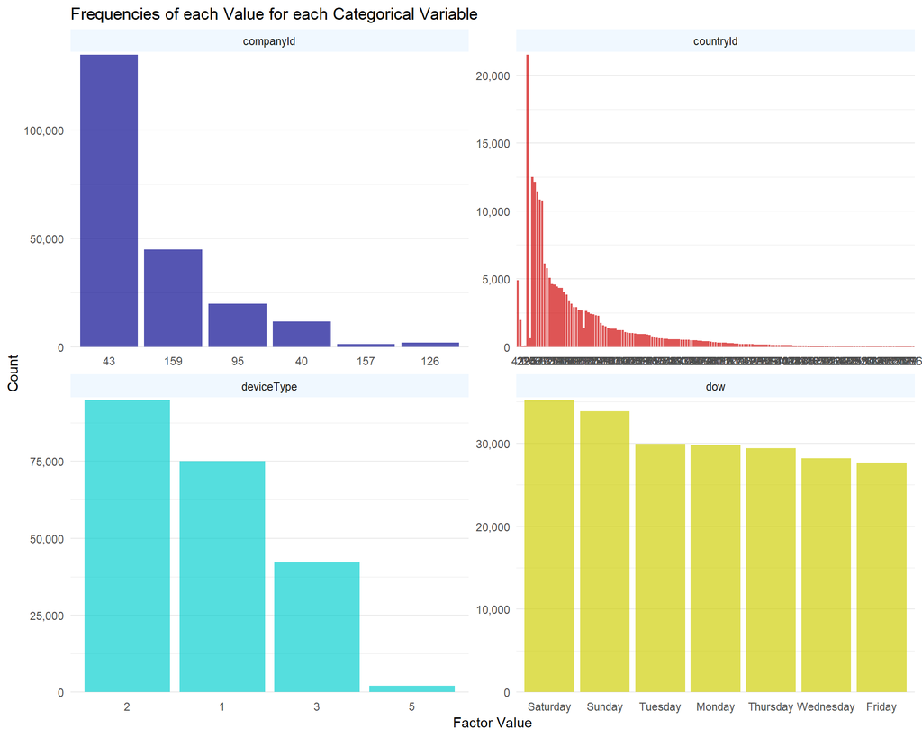

```r
advertising_train_long_cat$Variable <- as.factor(advertising_train_long_cat$Variable)
advertising_train_long_cat$Value <- as.factor(advertising_train_long_cat$Value)
ggplot(advertising_train_long_cat) +
  geom_bar(aes(x = fct_infreq(Value),
               fill = Variable),
           show.legend = F, alpha = 2/3) +
  facet_rep_wrap(~Variable,
                 repeat.tick.labels = T,
                 scales = "free") +
  scale_y_continuous(labels = comma,
                     expand = c(0.01, 0),
                     "Count") +
  scale_x_discrete("Factor Value") +
  scale_fill_manual(values = c("blue4", "red3", "cyan3", "yellow3")) +
  labs(title = "Frequencies of each Value for each Categorical Variable") +
  theme_minimal() +
  theme(panel.grid.major.x = element_blank(),
        panel.grid.minor.x = element_blank(),
        strip.background = element_rect(fill = "aliceblue",
                                        colour = NA))
```

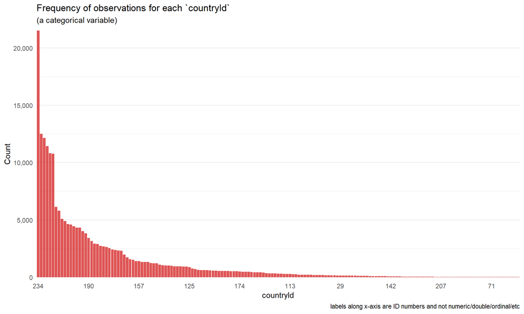

```r
country_labels <- levels(fct_infreq(advertising_train$countryId))[c(seq(1,
                                                                        length(levels(fct_infreq(advertising_train$countryId))),
                                                                        ceiling(length(levels(fct_infreq(advertising_train$countryId)))/10)))]
ggplot(advertising_train) +
  geom_bar(aes(x = fct_infreq(countryId)),
           fill = "red3", alpha = 2/3) +
  scale_y_continuous(labels = comma,
                     expand = c(0.01, 0),
                     "Count") +
  scale_x_discrete(breaks = country_labels,
                   "countryId") +
  labs(title = "Frequency of observations for each \`countryId\`",
       subtitle = "(a categorical variable)",
       caption = "labels along x-axis are ID numbers and not numeric/double/ordinal/etc") +
  theme_minimal() +
  theme(panel.grid.major.x = element_blank(),
        panel.grid.minor.x = element_blank())
```

### 1.2.5 Univariate Plots

#### 1.2.5.1 Numeric Variables

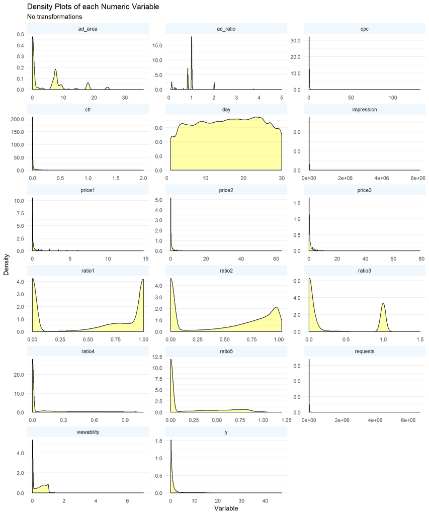

```r
ggplot(advertising_train_long_num) +
  geom_density(aes(x = Value),
               fill = "yellow",
               alpha = 1/3) +
  facet_rep_wrap(~Variable,
                 repeat.tick.labels = T,
                 scales = "free",
                 ncol = 3) +
  scale_y_continuous(labels = comma_format(accuracy = 0.1)) +
  labs(title = "Density Plots of each Numeric Variable",
       subtitle = "No transformations",
       x = "Variable",
       y = "Density")+
  theme_minimal() +
  theme(panel.grid.major.x = element_blank(),
        panel.grid.minor.x = element_blank(),
        strip.background = element_rect(fill = "aliceblue",
                                        colour = NA))
```

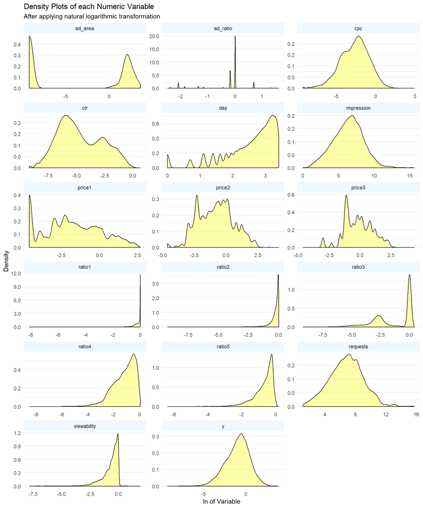

```r
ggplot(advertising_train_long_num) +
  geom_density(aes(x = log(Value)),
               fill = "yellow",
               alpha = 1/3) +
  facet_rep_wrap(~Variable,
                 repeat.tick.labels = T,
                 scales = "free",
                 ncol = 3) +
  scale_y_continuous(labels = comma_format(accuracy = 0.1)) +
  labs(title = "Density Plots of each Numeric Variable",
       subtitle = "After applying natural logarithmic transformation",
       x = "ln of Variable",
       y = "Density") +
  theme_minimal() +
  theme(panel.grid.major.x = element_blank(),
        panel.grid.minor.x = element_blank(),
        strip.background = element_rect(fill = "aliceblue",
                                        colour = NA))
```

#### 1.2.5.2 Logarithmic Transformations

It was observed from the plots above that natural logarithmic transformations were applicable for descriptive features `cpc`, `impression`, and potentially `ctr`. Target feature `y` was also suitable for a logarithmic transformation.

```r
advertising_train <- mutate(advertising_train,
                            "ln_cpc" = log(cpc + 0.005),
                            "ln_ctr" = log(ctr + 0.005),
                            "ln_impr" = log(impression + 0.005),
                            "ln_req" = log(requests + 0.005),
                            "ln_y" = log(y + 0.005))
sample_adv <- sample_n(advertising_train, 20)
kable_styling(kable(sample_adv[ , 1 : floor(ncol(sample_adv)/2) ],
                    format.args = list(digits = 3),
                    caption = "Sample of advertising\\_train Data Frame After Logarithmic Transformations"),
              font_size = 10, bootstrap_options = c("striped"),
              full_width = F)
kable_styling(kable(sample_adv[ , c(1, seq(from = floor(ncol(sample_adv)/2)+1,
                                           to = ncol(sample_adv),
                                           by = 1))],
                    format.args = list(digits = 3),
                    caption = "Sample of advertising\\_train Data Frame After Logarithmic Transformations (cont)"),
              font_size = 10, bootstrap_options = c("striped"),
              full_width = F)
```

Sample of advertising_train Data Frame After Logarithmic Transformations

| case_id | companyId | countryId | deviceType | day | dow | price1 | price2 | price3 | ad_area | ad_ratio | requests | impression |
| --- | --- | --- | --- | --- | --- | --- | --- | --- | --- | --- | --- | --- |
| 33238 | 95 | 234 | 1 | 6 | Thursday | 0.03 | 0.67 | 1.340 | 1.6000 | 0.1562 | 11226 | 6645 |
| 206040 | 159 | 75 | 3 | 29 | Saturday | 0.01 | 0.22 | 0.419 | 0.0001 | 1.0000 | 0 | 0 |
| 110040 | 43 | 234 | 2 | 16 | Sunday | 0.74 | 1.81 | 3.623 | 6.5520 | 0.1236 | 0 | 0 |
| 149869 | 43 | 56 | 2 | 22 | Saturday | 1.13 | 1.13 | 1.135 | 0.0001 | 1.0000 | 15 | 11 |
| 94219 | 43 | 56 | 1 | 14 | Friday | 0.00 | 0.00 | 0.000 | 0.0001 | 1.0000 | 1376 | 1376 |
| 189502 | 43 | 105 | 2 | 27 | Thursday | 3.39 | 3.99 | 7.985 | 8.7300 | 0.0928 | 0 | 0 |
| 206903 | 43 | 56 | 2 | 29 | Saturday | 0.00 | 0.00 | 0.000 | 16.5000 | 0.3788 | 2192 | 2189 |
| 194030 | 159 | 200 | 2 | 27 | Thursday | 0.06 | 0.12 | 0.385 | 0.0001 | 1.0000 | 9866 | 8939 |
| 85425 | 43 | 234 | 3 | 13 | Thursday | 0.00 | 0.00 | 0.000 | 0.0001 | 1.0000 | 0 | 0 |
| 77014 | 40 | 79 | 1 | 12 | Wednesday | 0.10 | 0.10 | 0.200 | 0.0001 | 1.0000 | 0 | 0 |
| 62258 | 43 | 125 | 3 | 10 | Monday | 0.00 | 0.00 | 0.000 | 0.0001 | 1.0000 | 0 | 0 |
| 78253 | 43 | 234 | 2 | 12 | Wednesday | 0.25 | 0.57 | 1.150 | 6.5520 | 0.1236 | 618034 | 157407 |
| 57709 | 43 | 57 | 2 | 9 | Sunday | 0.00 | 0.00 | 0.000 | 6.5520 | 0.1236 | 0 | 0 |
| 21842 | 43 | 184 | 1 | 4 | Tuesday | 0.19 | 0.39 | 0.775 | 0.0001 | 1.0000 | 365 | 317 |
| 110297 | 43 | 171 | 2 | 16 | Sunday | 0.11 | 0.21 | 0.399 | 6.5520 | 0.1236 | 0 | 0 |
| 10856 | 43 | 197 | 3 | 3 | Monday | 0.00 | 0.00 | 0.000 | 0.0001 | 1.0000 | 669 | 665 |
| 176875 | 43 | 56 | 2 | 25 | Tuesday | 5.96 | 5.96 | 5.956 | 0.0001 | 1.0000 | 18351 | 936 |
| 39418 | 43 | 202 | 2 | 7 | Friday | 0.00 | 0.00 | 0.000 | 7.5000 | 0.8333 | 50634 | 44745 |
| 174732 | 43 | 57 | 2 | 25 | Tuesday | 8.85 | 8.85 | 8.850 | 0.0001 | 1.0000 | 3548 | 152 |
| 186422 | 43 | 105 | 1 | 26 | Wednesday | 0.24 | 1.85 | 3.707 | 3.2000 | 0.3125 | 176 | 88 |

Sample of advertising_train Data Frame After Logarithmic Transformations (cont)

| case_id | cpc | ctr | viewability | ratio1 | ratio2 | ratio3 | ratio4 | ratio5 | y | ln_cpc | ln_ctr | ln_impr | ln_req | ln_y |
| --- | --- | --- | --- | --- | --- | --- | --- | --- | --- | --- | --- | --- | --- | --- |
| 33238 | 0.7617 | 0.0008 | 0.172 | 0.675 | 0.7226 | 0.0370 | 0.6549 | 0.308 | 0.3715 | -0.266 | -5.150 | 8.80 | 9.33 | -0.9769 |
| 206040 | 0.0000 | 0.0000 | 0.000 | 0.000 | 0.0000 | 0.0000 | 0.0000 | 0.000 | 0.2845 | -5.298 | -5.298 | -5.30 | -5.30 | -1.2394 |
| 110040 | 0.0000 | 0.0000 | 0.000 | 0.000 | 0.0000 | 0.0000 | 0.0000 | 0.000 | 4.3572 | -5.298 | -5.298 | -5.30 | -5.30 | 1.4730 |
| 149869 | 0.0202 | 0.0909 | 0.857 | 1.000 | 0.8182 | 1.0000 | 0.0000 | 0.000 | 0.9125 | -3.681 | -2.344 | 2.40 | 2.71 | -0.0861 |
| 94219 | 0.0124 | 0.2006 | 0.774 | 1.000 | 0.8663 | 0.0603 | 0.0094 | 0.931 | 1.3439 | -4.051 | -1.582 | 7.23 | 7.23 | 0.2993 |
| 189502 | 0.0000 | 0.0000 | 0.000 | 0.000 | 0.0000 | 0.0000 | 0.0000 | 0.000 | 1.1885 | -5.298 | -5.298 | -5.30 | -5.30 | 0.1769 |
| 206903 | 0.1001 | 0.0046 | 0.822 | 1.000 | 0.8776 | 1.0000 | 0.0000 | 0.000 | 0.6048 | -2.253 | -4.646 | 7.69 | 7.69 | -0.4946 |
| 194030 | 0.1079 | 0.0019 | 0.487 | 0.817 | 0.9337 | 1.0004 | 0.0000 | 0.000 | 0.1689 | -2.181 | -4.976 | 9.10 | 9.20 | -1.7491 |
| 85425 | 0.0000 | 0.0000 | 0.000 | 0.000 | 0.0000 | 0.0000 | 0.0000 | 0.000 | 0.7000 | -5.298 | -5.298 | -5.30 | -5.30 | -0.3496 |
| 77014 | 0.0000 | 0.0000 | 0.000 | 0.000 | 0.0000 | 0.0000 | 0.0000 | 0.000 | 0.0564 | -5.298 | -5.298 | -5.30 | -5.30 | -2.7897 |
| 62258 | 0.0000 | 0.0000 | 0.000 | 0.000 | 0.0000 | 0.0000 | 0.0000 | 0.000 | 0.2220 | -5.298 | -5.298 | -5.30 | -5.30 | -1.4830 |
| 78253 | 2.5738 | 0.0004 | 0.509 | 0.636 | 0.6003 | 1.0006 | 0.0000 | 0.000 | 0.3221 | 0.947 | -5.221 | 11.97 | 13.33 | -1.1176 |
| 57709 | 0.0000 | 0.0000 | 0.000 | 0.000 | 0.0000 | 0.0000 | 0.0000 | 0.000 | 0.1327 | -5.298 | -5.298 | -5.30 | -5.30 | -1.9824 |
| 21842 | 0.0200 | 0.0410 | 1.010 | 0.880 | 0.8738 | 0.0757 | 0.2461 | 0.678 | 0.5463 | -3.689 | -3.079 | 5.76 | 5.90 | -0.5955 |
| 110297 | 0.0000 | 0.0000 | 0.000 | 0.000 | 0.0000 | 0.0000 | 0.0000 | 0.000 | 0.0615 | -5.298 | -5.298 | -5.30 | -5.30 | -2.7104 |
| 10856 | 0.0252 | 0.0662 | 0.973 | 1.000 | 0.9955 | 0.0000 | 0.8211 | 0.177 | 1.4475 | -3.500 | -2.642 | 6.50 | 6.51 | 0.3733 |
| 176875 | 0.0120 | 0.7041 | 0.923 | 0.973 | 0.9701 | 1.0000 | 0.0000 | 0.000 | 0.2602 | -4.075 | -0.344 | 6.84 | 9.82 | -1.3272 |
| 39418 | 0.2683 | 0.0002 | 0.189 | 1.000 | 0.6481 | 1.0000 | 0.0000 | 0.000 | 0.0525 | -1.297 | -5.259 | 10.71 | 10.83 | -2.8557 |
| 174732 | 0.3171 | 0.0263 | 1.010 | 0.993 | 0.0263 | 1.0000 | 0.0000 | 0.000 | 0.1084 | -1.133 | -3.464 | 5.02 | 8.17 | -2.1772 |
| 186422 | 0.0346 | 0.0455 | 0.622 | 0.364 | 1.0000 | 0.1250 | 0.0568 | 0.818 | 0.2979 | -3.229 | -2.986 | 4.48 | 5.17 | -1.1942 |

#### 1.2.5.3 Comparison of Transformed Features to Normal Curve

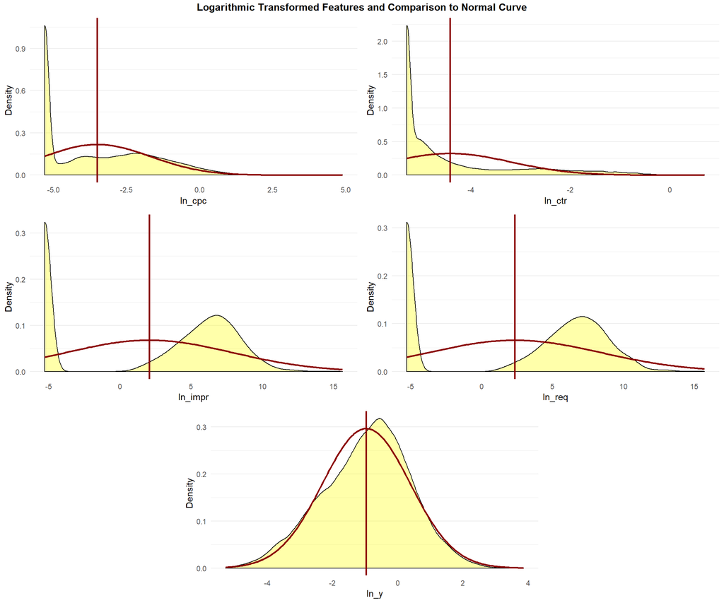

```r
finite_cpc <- filter(advertising_train,
                     is.finite(ln_cpc))
p_cpc <- ggplot(finite_cpc) +
  geom_density(aes(x = ln_cpc),
               fill = "yellow", alpha = 1/3) +
  stat_function(geom = "path", fun = dnorm,
                n = 200, col = "red4", size = 1,
                args = list(mean(finite_cpc$ln_cpc),
                            sd(finite_cpc$ln_cpc))) +
  geom_vline(xintercept = mean(finite_cpc$ln_cpc),
             col = "red4", size = 1) +
  ylab("Density") +
  theme_minimal() +
  theme(panel.grid.major.x = element_blank(),
        panel.grid.minor.x = element_blank())
finite_ctr <- filter(advertising_train,
                     is.finite(ln_ctr))
p_ctr <- ggplot(finite_ctr) +
  geom_density(aes(x = ln_ctr),
               fill = "yellow", alpha = 1/3) +
  stat_function(geom = "path", fun = dnorm,
                n = 200, col = "red4", size = 1,
                args = list(mean(finite_ctr$ln_ctr),
                            sd(finite_ctr$ln_ctr))) +
  geom_vline(xintercept = mean(finite_ctr$ln_ctr),
             col = "red4", size = 1) +
  ylab("Density") +
  theme_minimal() +
  theme(panel.grid.major.x = element_blank(),
        panel.grid.minor.x = element_blank())
finite_impr <- filter(advertising_train,
                      is.finite(ln_impr))
p_impr <- ggplot(finite_impr) +
  geom_density(aes(x = ln_impr),
               fill = "yellow", alpha = 1/3) +
  stat_function(geom = "path", fun = dnorm,
                n = 200, col = "red4", size = 1,
                args = list(mean(finite_impr$ln_impr),
                            sd(finite_impr$ln_impr))) +
  geom_vline(xintercept = mean(finite_cpc$ln_impr),
             col = "red4", size = 1) +
  ylab("Density") +
  theme_minimal() +
  theme(panel.grid.major.x = element_blank(),
        panel.grid.minor.x = element_blank())
finite_req <- filter(advertising_train,
                     is.finite(ln_req))
p_req <- ggplot(finite_req) +
  geom_density(aes(x = ln_req),
               fill = "yellow", alpha = 1/3) +
  stat_function(geom = "path", fun = dnorm,
                n = 200, col = "red4", size = 1,
                args = list(mean(finite_req$ln_req),
                            sd(finite_req$ln_req))) +
  geom_vline(xintercept = mean(finite_cpc$ln_req),
             col = "red4", size = 1) +
  ylab("Density") +
  theme_minimal() +
  theme(panel.grid.major.x = element_blank(),
        panel.grid.minor.x = element_blank())
finite_y <- filter(advertising_train,
                   is.finite(ln_y))
p_y <- ggplot(finite_y) +
  geom_density(aes(x = ln_y),
               fill = "yellow", alpha = 1/3) +
  stat_function(geom = "path", fun = dnorm,
                n = 200, col = "red4", size = 1,
                args = list(mean(finite_y$ln_y),
                            sd(finite_y$ln_y))) +
  geom_vline(xintercept = mean(finite_cpc$ln_y),
             col = "red4", size = 1) +
  ylab("Density") +
  theme_minimal() +
  theme(panel.grid.major.x = element_blank(),
        panel.grid.minor.x = element_blank())
ln_vars_title <- textGrob("Logarithmic Transformed Features and Comparison to Normal Curve",
                          gp = gpar(fontface = "bold"))
grid.arrange(top = ln_vars_title,
             p_cpc, p_ctr,
             p_impr, p_req,
             p_y,
             layout_matrix = matrix(c(1,1,2,2,
                                      3,3,4,4,
                                      NA,5,5,NA),
                                    ncol = 4,
                                    byrow = T))
```

### 1.2.6 Multivariate Plots

After transformation, grouping the `ln_ctr` distribution by level within the `companyId` factor revealed several distinct distributions. The distribution for `companyId` == 43 still appeared bimodal, which possibly indicated a further dimension of the multivariate relationship.

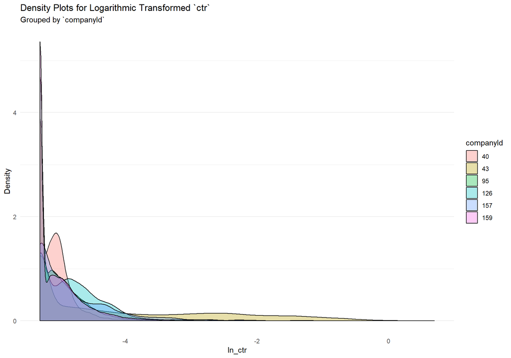

```r
ggplot(advertising_train) +
  geom_density(aes(x = ln_ctr, fill = companyId),
               alpha = 1/3) +
  labs(title = "Density Plots for Logarithmic Transformed \`ctr\`",
       subtitle = "Grouped by \`companyId\`",
       y = "Density") +
  theme_minimal() +
  theme(panel.grid.major.x = element_blank(),
        panel.grid.minor.x = element_blank())
```

Producing separate density plots for each level within `deviceType` suggested some trivariate relationship between `ln_ctr`, `companyId`, and `deviceType`. The effect of facetting by `deviceType` was particularly apparent when examining `companyId` == 43, yet it still did not yield Gaussian distributions.

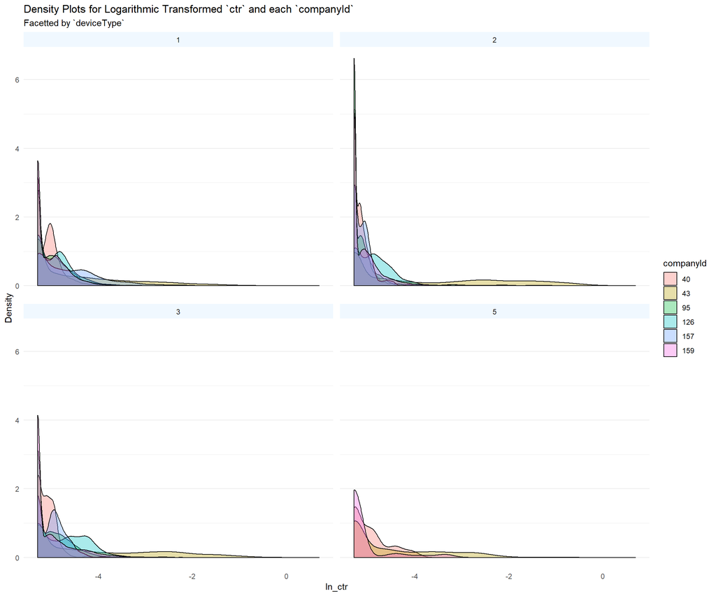

```r
ggplot(advertising_train) +
  geom_density(aes(x = ln_ctr, fill = companyId),
               alpha = 1/3) +
  facet_rep_wrap(~deviceType) +
  labs(title = "Density Plots for Logarithmic Transformed \`ctr\` and each \`companyId\`",
       subtitle = "Facetted by \`deviceType\`",
       y = "Density") +
  theme_minimal() +
  theme(panel.grid.major.x = element_blank(),
        panel.grid.minor.x = element_blank(),
        strip.background = element_rect(fill = "aliceblue",
                                        colour = NA))
```

As above for `ln_ctr`, grouping by `companyId` and facetting by `deviceType` revealed a multivariate relationship between aforementioned descriptive features and the transformed `ln_cpc`.

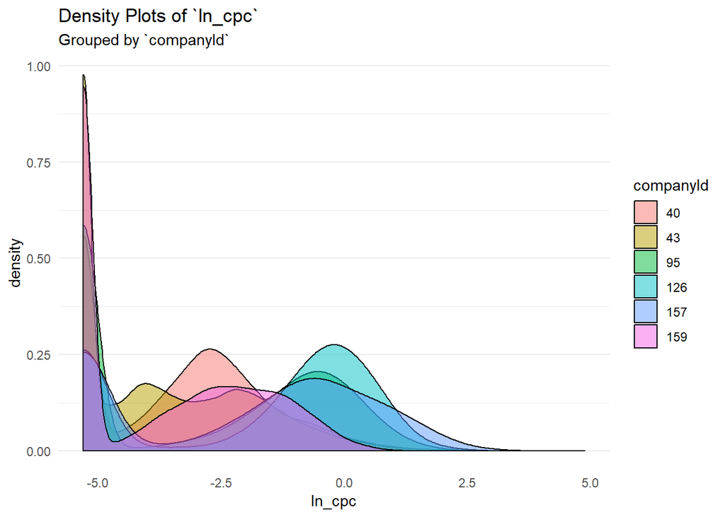

```r
ggplot(advertising_train) +
  geom_density(aes(x = ln_cpc, fill = companyId),
               alpha = 1/2) +
  labs(title = "Density Plots of \`ln_cpc\`",
       subtitle = "Grouped by \`companyId\`",
       ylab = "Density") +
  theme_minimal() +
  theme(panel.grid.major.x = element_blank(),
        panel.grid.minor.x = element_blank())
```

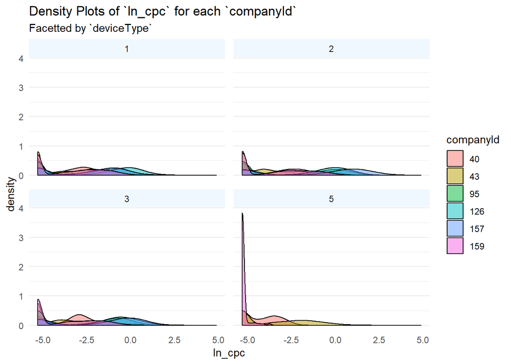

```r
ggplot(advertising_train) +
  geom_density(aes(x = ln_cpc, fill = companyId),
               alpha = 1/2) +
  facet_rep_wrap(~deviceType) +
  labs(title = "Density Plots of \`ln_cpc\` for each \`companyId\`",
       subtitle = "Facetted by \`deviceType\`",
       ylab = "Density") +
  theme_minimal() +
  theme(panel.grid.major.x = element_blank(),
        panel.grid.minor.x = element_blank(),
        strip.background = element_rect(fill = "aliceblue",
                                        colour = NA))
```

Each of the pricing features, (`price1`, `price2`, `price3`) were not suitably transformed by either logarithmic, square root, or cube root. Logarithmic transformations appeared to spread the data the most, but these transformations considerably diverged from a symmetrical normal distribution. Further grouping by `deviceType` did not reveal Gaussian distributions.

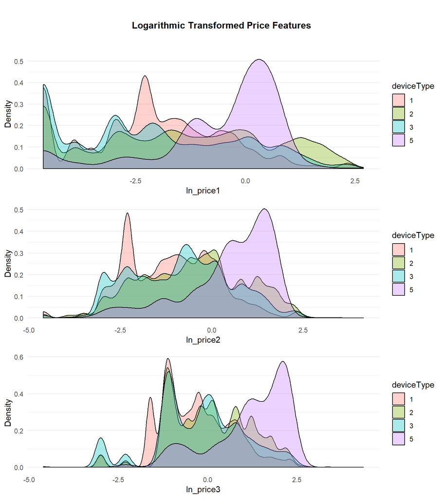

```r
price_trans <- mutate(advertising_train,
                      "ln_price1" = log(price1),
                      "ln_price2" = log(price2),
                      "ln_price3" = log(price3))
p_price1_trans <- ggplot(price_trans) +
  geom_density(aes(x = ln_price1, fill = deviceType),
               alpha = 1/3) +
  labs(y = "Density") +
  theme_minimal() +
  theme(panel.grid.major.x = element_blank(),
        panel.grid.minor.x = element_blank())
p_price2_trans <- ggplot(price_trans) +
  geom_density(aes(x = ln_price2, fill = deviceType),
               alpha = 1/3) +
  labs(y = "Density") +
  theme_minimal() +
  theme(panel.grid.major.x = element_blank(),
        panel.grid.minor.x = element_blank())
p_price3_trans <- ggplot(price_trans) +
  geom_density(aes(x = ln_price3, fill = deviceType),
               alpha = 1/3) +
  labs(y = "Density") +
  theme_minimal() +
  theme(panel.grid.major.x = element_blank(),
        panel.grid.minor.x = element_blank())
price_vars_title <- textGrob("Logarithmic Transformed Price Features",
                             gp = gpar(fontface = "bold"))
grid.arrange(price_vars_title,
             p_price1_trans, p_price2_trans,
             p_price3_trans,
             layout_matrix = matrix(c(1,
                                      2,
                                      2,
                                      2,
                                      3,
                                      3,
                                      3,
                                      4,
                                      4,
                                      4),
                                    ncol = 1,
                                    byrow = T))
```

Box-Cox transformations with a range of lamda values also did not convert the price features into distributions that resembled a normal curve.

```r
boxcox <- function(x, lambda = 1) {

  (x^(lambda) - 1 /
     (lambda))

}
box_grobs_2 <- list()
box_grobs_higher <- list()
for (i in 1:length(seq(0.025, 0.3, 0.025))) {

  j <- seq(0.025, 0.3, 0.025)[i]

  boxcox_price <- mutate(advertising_train,
                         "bc_price1" = boxcox(x = price1,
                                              lambda = j),
                         "bc_price2" = boxcox(x = price2,
                                              lambda = j),
                         "bc_price3" = boxcox(x = price3,
                                              lambda = j))

  bc_colnames <- colnames(boxcox_price)[str_detect(colnames(boxcox_price), "bc_price")]

  for (k in bc_colnames) {

    m <- which(bc_colnames %in% k)

    box_grobs_2[[m]] <- ggplot(select(boxcox_price,
                                      k, deviceType)) +
      geom_density(aes(x = .data[[k]], fill = deviceType),
                   alpha = 1/3) +
      labs(title = paste("Lambda = ", j)) +
      ylab("Density") + xlab(k) +
      theme_minimal() +
      theme(panel.grid.major.x = element_blank(),
            panel.grid.minor.x = element_blank())

  }

  box_grobs_higher[[i]] <- box_grobs_2

}
density_by_lambda <- list()
for (i in 1:12) {

  density_by_lambda[[i]] <-  do.call(what = grid.arrange,
                                     args = list(grobs = box_grobs_higher[[i]],
                                                 nrow = 1))

}
```

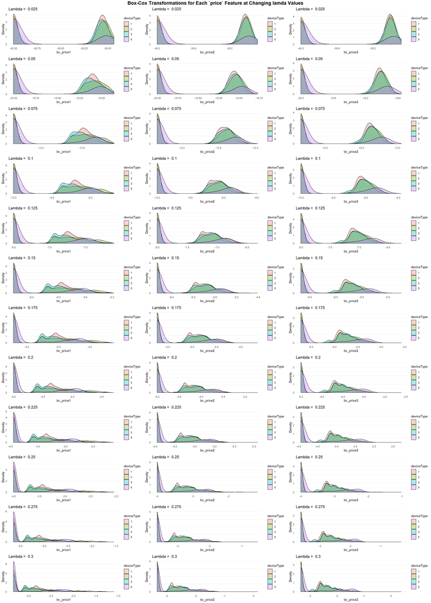

```r
do.call(what = grid.arrange,
        args = list(grobs = density_by_lambda,
                    top = textGrob("Box-Cox Transformations for Each \`price\` Feature at Changing lamda Values",
                                   gp = gpar(fontsize=16,
                                             fontface = "bold")),
                    ncol = 1))
```

The remaining numeric features (`ad_area`, `ad_ratio`, `day`, `ratio1`, `ratio2`, `ratio3`, `ratio4`, `ratio5`, and `viewability`) were not able to be transformed to distributions that approached normal curves via root or logarithmic methods. Despite the accompanying documentation for the prescribed dataset, the `ad_area` and `day` may not strictly be classed as numeric/double variables. Considering the low range, `ad_area` could be intepreted as an identifier, and so categorical. The feature `day`, values 1 - 30, is better interpreted as an ordinal or time value. However, time series forecasting is outside the scope of this project, and so the `day` feature will be largely ignored from the model and only used for partitioning.

#### 1.2.6.1 Data Normalisation

As outlined in **Fundamentals of Machine Learning**, the below formula was used for normalising the data:

$$a^{'}_{i} = \left( \frac{a_i-min(a)}{max(a)-min(a)} \right) \times (high - low) + low$$

Where $a$ is the feature, whether descriptive or target, $high$ is the highest value in the normalised data range, and $low$ is the lowest value in the normalised data range. A range of 0 - 1 was chosen, so these values were used for $low$ and $high$ respectively.

```r
normalise <- function(x) {

  x[is.infinite(x)] <- NA

  (((x - min(x, na.rm = T)) /
      (max(x, na.rm = T) - min(x, na.rm = T))) * (1 - 0) + 0)

}
num_feats <- select(advertising_train,
                    case_id,
                    which(sapply(advertising_train, class)=="numeric"))
for ( i in colnames(num_feats)) {

  newfeat <- paste0("norm_", i)

  advertising_train[[newfeat]] <- normalise(num_feats[[i]])

  advertising_train[[newfeat]][is.na(advertising_train[[newfeat]])] <- advertising_train[[i]]

}
sample_adv <- sample_n(advertising_train, 20)
kable_styling(kable(sample_adv[, 1:floor(ncol(sample_adv)/3)],
                    caption = "Sample of advertising\\_train Data Frame with Normalised Numeric Features (1/3)",
                    format.args = list(digits = 2, scientific = F,
                                       big.mark = ",")),
              font_size = 10, bootstrap_options = c("striped"),
              full_width = T)
```

Sample of advertising_train Data Frame with Normalised Numeric Features (1/3)

| case_id | companyId | countryId | deviceType | day | dow | price1 | price2 | price3 | ad_area | ad_ratio | requests | impression | cpc | ctr | viewability |
| --- | --- | --- | --- | --- | --- | --- | --- | --- | --- | --- | --- | --- | --- | --- | --- |
| 29,597 | 43 | 56 | 1 | 5 | Wednesday | 0.00 | 0.00 | 0.00 | 9.0000 | 0.69 | 97 | 97 | 0.0403 | 0.0103 | 0.38 |
| 24,162 | 43 | 234 | 2 | 4 | Tuesday | 0.91 | 0.91 | 0.91 | 0.0001 | 1.00 | 20 | 12 | 0.0090 | 0.2500 | 1.00 |
| 109,746 | 43 | 186 | 2 | 16 | Sunday | 4.56 | 4.56 | 4.56 | 0.0001 | 1.00 | 1,076 | 86 | 0.0194 | 0.2558 | 0.95 |
| 183,192 | 43 | 197 | 1 | 26 | Wednesday | 0.00 | 0.00 | 0.00 | 7.5000 | 0.83 | 450 | 281 | 0.1236 | 0.0214 | 0.76 |
| 118,818 | 43 | 227 | 1 | 18 | Tuesday | 0.31 | 0.86 | 1.72 | 0.0001 | 1.00 | 0 | 0 | 0.0000 | 0.0000 | 0.00 |
| 114,599 | 159 | 38 | 1 | 17 | Monday | 0.00 | 0.00 | 0.00 | 0.0001 | 1.00 | 0 | 0 | 0.0000 | 0.0000 | 0.00 |
| 61,910 | 43 | 100 | 1 | 10 | Monday | 0.02 | 0.16 | 0.32 | 7.5000 | 0.83 | 3,832 | 650 | 0.0312 | 0.0031 | 0.18 |
| 89,437 | 95 | 77 | 3 | 14 | Friday | 0.01 | 0.42 | 0.83 | 7.5000 | 0.83 | 0 | 0 | 0.0000 | 0.0000 | 0.00 |
| 65,603 | 43 | 234 | 2 | 10 | Monday | 0.00 | 0.00 | 0.00 | 6.5520 | 0.12 | 800 | 655 | 0.4440 | 0.0046 | 0.41 |
| 166,342 | 159 | 57 | 3 | 24 | Monday | 0.00 | 0.00 | 0.00 | 0.0001 | 1.00 | 595 | 589 | 0.1045 | 0.0051 | 0.72 |
| 121,407 | 159 | 12 | 3 | 18 | Tuesday | 0.15 | 0.57 | 1.14 | 0.0001 | 1.00 | 813 | 762 | 0.3308 | 0.0026 | 0.41 |
| 37,753 | 43 | 202 | 2 | 6 | Thursday | 0.00 | 0.00 | 0.00 | 18.0000 | 2.00 | 12,823 | 11,947 | 0.1197 | 0.0026 | 0.53 |
| 177,963 | 43 | 77 | 1 | 25 | Tuesday | 0.07 | 0.32 | 0.64 | 7.5000 | 0.83 | 7,705 | 4,612 | 0.2028 | 0.0013 | 0.31 |
| 63,965 | 43 | 224 | 2 | 10 | Monday | 1.13 | 1.13 | 1.13 | 0.0001 | 1.00 | 11 | 11 | 0.0024 | 0.1818 | 1.00 |
| 1,567 | 43 | 127 | 1 | 1 | Saturday | 0.16 | 0.32 | 0.63 | 7.5000 | 0.83 | 2,487 | 120 | 0.0412 | 0.0083 | 0.48 |
| 39,767 | 43 | 103 | 1 | 7 | Friday | 0.14 | 0.36 | 0.73 | 7.5000 | 0.83 | 9,243 | 4,823 | 0.2525 | 0.0023 | 0.46 |
| 154,004 | 159 | 234 | 2 | 22 | Saturday | 0.02 | 0.15 | 0.29 | 0.0001 | 1.00 | 5,369 | 5,084 | 0.6905 | 0.0030 | 0.50 |
| 64,948 | 43 | 43 | 3 | 10 | Monday | 3.40 | 3.40 | 3.40 | 0.0001 | 1.00 | 0 | 0 | 0.0000 | 0.0000 | 0.00 |
| 47,975 | 95 | 166 | 1 | 8 | Saturday | 0.01 | 0.20 | 0.40 | 7.5000 | 0.83 | 0 | 0 | 0.0000 | 0.0000 | 0.00 |
| 131,916 | 43 | 12 | 1 | 19 | Wednesday | 0.00 | 0.00 | 0.00 | 9.0000 | 1.00 | 0 | 0 | 0.0000 | 0.0000 | 0.00 |

```r
kable_styling(kable(sample_adv[, c(1,
                                   seq(from = floor(ncol(sample_adv)/3)*1+1,
                                       to = floor(ncol(sample_adv)/3)*2,
                                       by = 1))],
                    caption = "Sample of advertising\\_train Data Frame with Normalised Numeric Features (2/3)",
                    format.args = list(digits = 2, scientific = F,
                                       big.mark = ",")),
              font_size = 10, bootstrap_options = c("striped"),
              full_width = T)
```

Sample of advertising_train Data Frame with Normalised Numeric Features (2/3)

| case_id | ratio1 | ratio2 | ratio3 | ratio4 | ratio5 | y | ln_cpc | ln_ctr | ln_impr | ln_req | ln_y | norm_case_id | norm_day | norm_price1 | norm_price2 | norm_price3 |
| --- | --- | --- | --- | --- | --- | --- | --- | --- | --- | --- | --- | --- | --- | --- | --- | --- |
| 29,597 | 1.00 | 0.86 | 0.000 | 0.00 | 1.00 | 0.352 | -3.09 | -4.2 | 4.6 | 4.6 | -1.03 | 0.1382 | 0.14 | 0.00000 | 0.0000 | 0.0000 |
| 24,162 | 0.92 | 0.33 | 1.000 | 0.00 | 0.00 | 1.352 | -4.27 | -1.4 | 2.5 | 3.0 | 0.30 | 0.1128 | 0.10 | 0.06195 | 0.0144 | 0.0116 |
| 109,746 | 0.93 | 1.00 | 1.000 | 0.00 | 0.00 | 0.090 | -3.71 | -1.3 | 4.5 | 7.0 | -2.35 | 0.5125 | 0.52 | 0.31042 | 0.0722 | 0.0578 |
| 183,192 | 1.00 | 0.99 | 0.057 | 0.63 | 0.32 | 1.385 | -2.05 | -3.6 | 5.6 | 6.1 | 0.33 | 0.8555 | 0.86 | 0.00000 | 0.0000 | 0.0000 |
| 118,818 | 0.00 | 0.00 | 0.000 | 0.00 | 0.00 | 0.222 | -5.30 | -5.3 | -5.3 | -5.3 | -1.48 | 0.5549 | 0.59 | 0.02110 | 0.0136 | 0.0217 |
| 114,599 | 0.00 | 0.00 | 0.000 | 0.00 | 0.00 | 0.808 | -5.30 | -5.3 | -5.3 | -5.3 | -0.21 | 0.5352 | 0.55 | 0.00000 | 0.0000 | 0.0000 |
| 61,910 | 0.50 | 0.89 | 0.088 | 0.25 | 0.66 | 0.024 | -3.32 | -4.8 | 6.5 | 8.3 | -3.53 | 0.2891 | 0.31 | 0.00136 | 0.0025 | 0.0040 |
| 89,437 | 0.00 | 0.00 | 0.000 | 0.00 | 0.00 | 0.250 | -5.30 | -5.3 | -5.3 | -5.3 | -1.37 | 0.4177 | 0.45 | 0.00068 | 0.0067 | 0.0105 |
| 65,603 | 1.00 | 0.70 | 1.000 | 0.00 | 0.00 | 1.587 | -0.80 | -4.6 | 6.5 | 6.7 | 0.47 | 0.3064 | 0.31 | 0.00000 | 0.0000 | 0.0000 |
| 166,342 | 1.00 | 0.65 | 0.093 | 0.40 | 0.51 | 0.475 | -2.21 | -4.6 | 6.4 | 6.4 | -0.73 | 0.7768 | 0.79 | 0.00000 | 0.0000 | 0.0000 |
| 121,407 | 0.73 | 0.73 | 0.000 | 0.59 | 0.40 | 1.292 | -1.09 | -4.9 | 6.6 | 6.7 | 0.26 | 0.5670 | 0.59 | 0.01021 | 0.0090 | 0.0145 |
| 37,753 | 1.00 | 0.79 | 1.000 | 0.00 | 0.00 | 0.395 | -2.08 | -4.9 | 9.4 | 9.5 | -0.92 | 0.1763 | 0.17 | 0.00000 | 0.0000 | 0.0000 |
| 177,963 | 0.57 | 0.84 | 0.063 | 0.58 | 0.36 | 0.133 | -1.57 | -5.1 | 8.4 | 8.9 | -1.98 | 0.8311 | 0.83 | 0.00477 | 0.0051 | 0.0081 |
| 63,965 | 1.00 | 1.00 | 1.000 | 0.00 | 0.00 | 0.270 | -4.91 | -1.7 | 2.4 | 2.4 | -1.29 | 0.2987 | 0.31 | 0.07692 | 0.0179 | 0.0144 |
| 1,567 | 0.80 | 0.60 | 0.050 | 0.40 | 0.55 | 0.012 | -3.07 | -4.3 | 4.8 | 7.8 | -4.10 | 0.0073 | 0.00 | 0.01089 | 0.0051 | 0.0080 |
| 39,767 | 0.85 | 0.84 | 0.110 | 0.17 | 0.72 | 0.428 | -1.36 | -4.9 | 8.5 | 9.1 | -0.84 | 0.1857 | 0.21 | 0.00953 | 0.0057 | 0.0092 |
| 154,004 | 0.99 | 0.61 | 1.000 | 0.00 | 0.00 | 1.706 | -0.36 | -4.8 | 8.5 | 8.6 | 0.54 | 0.7192 | 0.72 | 0.00136 | 0.0024 | 0.0037 |
| 64,948 | 0.00 | 0.00 | 0.000 | 0.00 | 0.00 | 4.167 | -5.30 | -5.3 | -5.3 | -5.3 | 1.43 | 0.3033 | 0.31 | 0.23145 | 0.0539 | 0.0431 |
| 47,975 | 0.00 | 0.00 | 0.000 | 0.00 | 0.00 | 0.075 | -5.30 | -5.3 | -5.3 | -5.3 | -2.52 | 0.2240 | 0.24 | 0.00068 | 0.0032 | 0.0051 |
| 131,916 | 0.00 | 0.00 | 0.000 | 0.00 | 0.00 | 0.670 | -5.30 | -5.3 | -5.3 | -5.3 | -0.39 | 0.6161 | 0.62 | 0.00000 | 0.0000 | 0.0000 |

```r
kable_styling(kable(sample_adv[, c(1,
                                   seq(from = floor(ncol(sample_adv)/3)*2+1,
                                       to = floor(ncol(sample_adv)/3)*3,
                                       by = 1))],
                    caption = "Sample of advertising\\_train Data Frame with Normalised Numeric Features (3/3)",
                    format.args = list(digits = 2, scientific = F,
                                       big.mark = ",")),
              font_size = 10, bootstrap_options = c("striped"),
              full_width = T)
```

Sample of advertising_train Data Frame with Normalised Numeric Features (3/3)

| case_id | norm_ad_area | norm_ad_ratio | norm_requests | norm_impression | norm_cpc | norm_ctr | norm_viewability | norm_ratio1 | norm_ratio2 | norm_ratio3 | norm_ratio4 | norm_ratio5 | norm_y | norm_ln_cpc | norm_ln_ctr | norm_ln_impr |
| --- | --- | --- | --- | --- | --- | --- | --- | --- | --- | --- | --- | --- | --- | --- | --- | --- |
| 29,597 | 0.25 | 0.1243 | 0.0000145 | 0.0000159 | 0.000304 | 0.00515 | 0.054 | 1.00 | 0.83 | 0.000 | 0.00 | 0.83 | 0.00748 | 0.216 | 0.187 | 0.47 |
| 24,162 | 0.00 | 0.1864 | 0.0000030 | 0.0000020 | 0.000068 | 0.12500 | 0.143 | 0.92 | 0.32 | 0.667 | 0.00 | 0.00 | 0.02872 | 0.101 | 0.656 | 0.37 |
| 109,746 | 0.00 | 0.1864 | 0.0001606 | 0.0000141 | 0.000146 | 0.12790 | 0.136 | 0.93 | 0.97 | 0.667 | 0.00 | 0.00 | 0.00192 | 0.156 | 0.660 | 0.47 |
| 183,192 | 0.21 | 0.1525 | 0.0000671 | 0.0000461 | 0.000933 | 0.01070 | 0.109 | 1.00 | 0.96 | 0.038 | 0.58 | 0.26 | 0.02944 | 0.319 | 0.278 | 0.52 |
| 118,818 | 0.00 | 0.1864 | 0.0000000 | 0.0000000 | 0.000000 | 0.00000 | 0.000 | 0.00 | 0.00 | 0.000 | 0.00 | 0.00 | 0.00471 | 0.000 | 0.000 | 0.00 |
| 114,599 | 0.00 | 0.1864 | 0.0000000 | 0.0000000 | 0.000000 | 0.00000 | 0.000 | 0.00 | 0.00 | 0.000 | 0.00 | 0.00 | 0.01716 | 0.000 | 0.000 | 0.00 |
| 61,910 | 0.21 | 0.1525 | 0.0005718 | 0.0001066 | 0.000235 | 0.00155 | 0.025 | 0.50 | 0.86 | 0.058 | 0.23 | 0.55 | 0.00051 | 0.194 | 0.080 | 0.56 |
| 89,437 | 0.21 | 0.1525 | 0.0000000 | 0.0000000 | 0.000000 | 0.00000 | 0.000 | 0.00 | 0.00 | 0.000 | 0.00 | 0.00 | 0.00531 | 0.000 | 0.000 | 0.00 |
| 65,603 | 0.18 | 0.0082 | 0.0001194 | 0.0001074 | 0.003350 | 0.00230 | 0.059 | 1.00 | 0.68 | 0.667 | 0.00 | 0.00 | 0.03373 | 0.442 | 0.109 | 0.56 |
| 166,342 | 0.00 | 0.1864 | 0.0000888 | 0.0000966 | 0.000789 | 0.00255 | 0.103 | 1.00 | 0.63 | 0.062 | 0.37 | 0.42 | 0.01008 | 0.303 | 0.117 | 0.56 |
| 121,407 | 0.00 | 0.1864 | 0.0001213 | 0.0001249 | 0.002496 | 0.00130 | 0.059 | 0.73 | 0.72 | 0.000 | 0.55 | 0.34 | 0.02746 | 0.413 | 0.070 | 0.57 |
| 37,753 | 0.50 | 0.3898 | 0.0019133 | 0.0019584 | 0.000903 | 0.00130 | 0.075 | 1.00 | 0.77 | 0.667 | 0.00 | 0.00 | 0.00838 | 0.316 | 0.070 | 0.70 |
| 177,963 | 0.21 | 0.1525 | 0.0011497 | 0.0007560 | 0.001530 | 0.00065 | 0.045 | 0.57 | 0.82 | 0.042 | 0.53 | 0.30 | 0.00283 | 0.366 | 0.039 | 0.66 |
| 63,965 | 0.00 | 0.1864 | 0.0000016 | 0.0000018 | 0.000018 | 0.09090 | 0.143 | 1.00 | 0.97 | 0.667 | 0.00 | 0.00 | 0.00573 | 0.038 | 0.604 | 0.37 |
| 1,567 | 0.21 | 0.1525 | 0.0003711 | 0.0000197 | 0.000311 | 0.00415 | 0.068 | 0.80 | 0.58 | 0.033 | 0.37 | 0.46 | 0.00024 | 0.218 | 0.163 | 0.48 |
| 39,767 | 0.21 | 0.1525 | 0.0013792 | 0.0007906 | 0.001905 | 0.00115 | 0.066 | 0.85 | 0.82 | 0.074 | 0.16 | 0.60 | 0.00909 | 0.387 | 0.063 | 0.66 |
| 154,004 | 0.00 | 0.1864 | 0.0008011 | 0.0008334 | 0.005210 | 0.00150 | 0.072 | 0.99 | 0.60 | 0.667 | 0.00 | 0.00 | 0.03625 | 0.485 | 0.078 | 0.66 |
| 64,948 | 0.00 | 0.1864 | 0.0000000 | 0.0000000 | 0.000000 | 0.00000 | 0.000 | 0.00 | 0.00 | 0.000 | 0.00 | 0.00 | 0.08854 | 0.000 | 0.000 | 0.00 |
| 47,975 | 0.21 | 0.1525 | 0.0000000 | 0.0000000 | 0.000000 | 0.00000 | 0.000 | 0.00 | 0.00 | 0.000 | 0.00 | 0.00 | 0.00160 | 0.000 | 0.000 | 0.00 |
| 131,916 | 0.25 | 0.1864 | 0.0000000 | 0.0000000 | 0.000000 | 0.00000 | 0.000 | 0.00 | 0.00 | 0.000 | 0.00 | 0.00 | 0.01423 | 0.000 | 0.000 | 0.00 |

# 2 **Phase 2: Algorithm Implementation**

## 2.1 Overview

After considerable data cleaning, three machine learning algorithms were trained on the data. The models trained were k-Nearest Neighbours, Random Forest, and Decision Tree. The data itself was too large to use for training, so small subset was used instead. Some further data cleaning was required in order to prepare for the machine learning models. Bagging / bootstrapping methods were also implemented so as to achieve the Random Forest model.

## 2.2 Further Data Preparation

### 2.2.1 Checking for Infinite and NA values

```r
num_vars <- sapply(select(advertising_train,
                          -case_id), is.numeric)

num_vars <- num_vars[which(num_vars == T)]

adv_train_num_long <- gather(advertising_train,
                             names(num_vars),
                             key = "Variable",
                             value = "Value")

kable_styling(kable(summarise(group_by(adv_train_num_long,
                                       Variable),
                              "n finite" = sum(is.finite(Value)),
                              "n infinite" = sum(is.infinite(Value)),
                              "n non-NA" = sum(!is.na(Value)),
                              "n NA" = sum(is.na(Value))),
                    format.args = list(big.mark = ","),
                    caption = "Counts of Infinite and NA Observations for each Feature"),
              font_size = 10, bootstrap_options = c("striped"),
              full_width = F)
```

Counts of Infinite and NA Observations for each Feature

| Variable | n finite | n infinite | n non-NA | n NA |
| --- | --- | --- | --- | --- |
| ad_area | 214,128 | 0 | 214,128 | 0 |
| ad_ratio | 214,128 | 0 | 214,128 | 0 |
| cpc | 214,128 | 0 | 214,128 | 0 |
| ctr | 214,128 | 0 | 214,128 | 0 |
| day | 214,128 | 0 | 214,128 | 0 |
| impression | 214,128 | 0 | 214,128 | 0 |
| ln_cpc | 214,128 | 0 | 214,128 | 0 |
| ln_ctr | 214,128 | 0 | 214,128 | 0 |
| ln_impr | 214,128 | 0 | 214,128 | 0 |
| ln_req | 214,128 | 0 | 214,128 | 0 |
| ln_y | 214,128 | 0 | 214,128 | 0 |
| norm_ad_area | 214,128 | 0 | 214,128 | 0 |
| norm_ad_ratio | 214,128 | 0 | 214,128 | 0 |
| norm_case_id | 214,128 | 0 | 214,128 | 0 |
| norm_cpc | 214,128 | 0 | 214,128 | 0 |
| norm_ctr | 214,128 | 0 | 214,128 | 0 |
| norm_day | 214,128 | 0 | 214,128 | 0 |
| norm_impression | 214,128 | 0 | 214,128 | 0 |
| norm_ln_cpc | 214,128 | 0 | 214,128 | 0 |
| norm_ln_ctr | 214,128 | 0 | 214,128 | 0 |
| norm_ln_impr | 214,128 | 0 | 214,128 | 0 |
| norm_ln_req | 214,128 | 0 | 214,128 | 0 |
| norm_ln_y | 214,128 | 0 | 214,128 | 0 |
| norm_price1 | 214,128 | 0 | 214,128 | 0 |
| norm_price2 | 214,128 | 0 | 214,128 | 0 |
| norm_price3 | 214,128 | 0 | 214,128 | 0 |
| norm_ratio1 | 214,128 | 0 | 214,128 | 0 |
| norm_ratio2 | 214,128 | 0 | 214,128 | 0 |
| norm_ratio3 | 214,128 | 0 | 214,128 | 0 |
| norm_ratio4 | 214,128 | 0 | 214,128 | 0 |
| norm_ratio5 | 214,128 | 0 | 214,128 | 0 |
| norm_requests | 214,128 | 0 | 214,128 | 0 |
| norm_viewability | 214,128 | 0 | 214,128 | 0 |
| norm_y | 214,128 | 0 | 214,128 | 0 |
| price1 | 214,128 | 0 | 214,128 | 0 |
| price2 | 214,128 | 0 | 214,128 | 0 |
| price3 | 214,128 | 0 | 214,128 | 0 |
| ratio1 | 214,128 | 0 | 214,128 | 0 |
| ratio2 | 214,128 | 0 | 214,128 | 0 |
| ratio3 | 214,128 | 0 | 214,128 | 0 |
| ratio4 | 214,128 | 0 | 214,128 | 0 |
| ratio5 | 214,128 | 0 | 214,128 | 0 |
| requests | 214,128 | 0 | 214,128 | 0 |
| viewability | 214,128 | 0 | 214,128 | 0 |
| y | 214,128 | 0 | 214,128 | 0 |

### 2.2.2 Discretising Target Feature

Random Forests, Decision Trees, and K-Nearest Neighbours methods of machine learning function best when predicting categorical variables. As such, the transformed target feature, `norm\_ln\_y` was classified into six equal-width bins; 1 to 6.

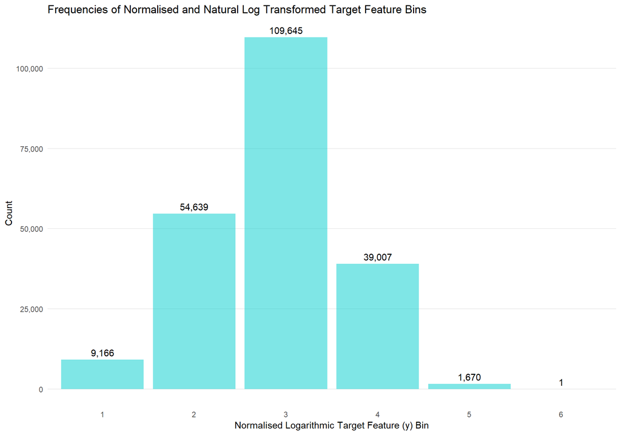

```r
advertising_train <- mutate(advertising_train,
                            "norm_ln_y_binned" = as.factor((norm_ln_y %/% 0.2) + 1))
ggplot(advertising_train) +
  geom_bar(aes(x = norm_ln_y_binned),
           stat = "count", bins = 10,
           fill = "cyan3", alpha = 1/2) +
  stat_count(aes(x = norm_ln_y_binned,
                 label = comma(..count..)),
             geom = "text",
             vjust = -0.5) +
  scale_x_discrete(limits = c(1:6),
                   "Normalised Logarithmic Target Feature (y) Bin") +
  scale_y_continuous(labels = comma,
                     breaks = seq(from = 0,
                                  to = 110000,
                                  by = 25000),
                     "Count") +
  ggtitle("Frequencies of Normalised and Natural Log Transformed Target Feature Bins") +
  theme_minimal() +
  theme(panel.grid.major.x = element_blank(),
        panel.grid.minor = element_blank())
```

### 2.2.3 Subsetting Data Frame

Due to constraints on computing power, it was deemed necessary to subset the data frame to a smaller number of rows.

```r
advertising_train_subset <- sample_n(advertising_train,
                                     size = 1998,
                                     replace = F)
advertising_train_subset <- rbind(advertising_train_subset,
                                  filter(advertising_train,
                                         norm_ln_y == max(norm_ln_y) |
                                           norm_ln_y == min(norm_ln_y)))
```

## 2.3 Feature Selection

```r
factor_vars <- sapply(advertising_train_subset,
                      is.factor)
factor_vars <- names(factor_vars[which(factor_vars == T)])
advertising_train_transformed <- select(advertising_train_subset,
                                        factor_vars,
                                        contains("norm"),
                                        -norm_ln_y,
                                        -norm_y)
```

```r
classif_task <- makeClassifTask(id = "target_binned",
                                data = advertising_train_transformed,
                                target = "norm_ln_y_binned")
```

### 2.3.1 Filter Methods

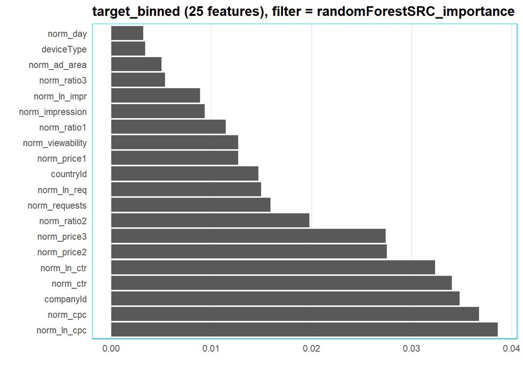

```r
filter_vals <- generateFilterValuesData(classif_task)
plotFilterValues(filter_vals) +
  coord_flip()+
  theme_minimal() +
  theme(panel.grid.major.y = element_blank(),
        panel.grid.minor = element_blank(),
        panel.border = element_rect(colour = "turquoise3",
                                    fill = NA),
        title = element_text(face = "bold"))
```

```r
filtered_task <- filterFeatures(classif_task,
                                fval = filter_vals,
                                perc = 0.4)
```

## 2.4 Implementing Three Machine Learning Models

```r
lrn <- makeFilterWrapper(learner = "classif.kknn",
                         fw.method = "FSelector_chi.squared")
param_set <- makeParamSet(makeDiscreteParam("fw.perc",
                                            values = seq(0.2,
                                                         0.5,
                                                         0.05)))
rdesc <- makeResampleDesc("CV", iters = 3)
res <- tuneParams(lrn,
                  task = classif_task,
                  resampling = rdesc,
                  par.set = param_set,
                  control = makeTuneControlGrid())
```

```
## [Tune] Started tuning learner classif.kknn.filtered for parameter set:
```

```
##             Type len Def                         Constr Req Tunable Trafo
## fw.perc discrete   -   - 0.2,0.25,0.3,0.35,0.4,0.45,0.5   -    TRUE     -
```

```
## With control class: TuneControlGrid
```

```
## Imputation value: 1
```

```
## [Tune-x] 1: fw.perc=0.2
```

```
## [Tune-y] 1: mmce.test.mean=0.4349987; time: 0.1 min
```

```
## [Tune-x] 2: fw.perc=0.25
```

```
## [Tune-y] 2: mmce.test.mean=0.4294970; time: 0.0 min
```

```
## [Tune-x] 3: fw.perc=0.3
```

```
## [Tune-y] 3: mmce.test.mean=0.4249955; time: 0.0 min
```

```
## [Tune-x] 4: fw.perc=0.35
```

```
## [Tune-y] 4: mmce.test.mean=0.4319987; time: 0.0 min
```

```
## [Tune-x] 5: fw.perc=0.4
```

```
## [Tune-y] 5: mmce.test.mean=0.4235060; time: 0.0 min
```

```
## [Tune-x] 6: fw.perc=0.45
```

```
## [Tune-y] 6: mmce.test.mean=0.4134960; time: 0.0 min
```

```
## [Tune-x] 7: fw.perc=0.5
```

```
## [Tune-y] 7: mmce.test.mean=0.4055015; time: 0.0 min
```

```
## [Tune] Result: fw.perc=0.5 : mmce.test.mean=0.4055015
```

```r
paste("The optimal percentage is:",
      res$x )
```

```
## [1] "The optimal percentage is: 0.5"
```

```r
paste("The misclassification error is:",
      res$y)
```

```
## [1] "The misclassification error is: 0.405501453477465"
```

```r
random_Ctrl <- makeFeatSelControlRandom(maxit = 10L)
rdesc2 <- makeResampleDesc("CV", iters = 3)
sfeats <- selectFeatures(learner = "classif.kknn",
                         task = classif_task,
                         resampling = rdesc2,
                         control = random_Ctrl,
                         show.info = F)
sfeats$x
```

```
##  [1] "companyId"       "deviceType"      "norm_day"
##  [4] "norm_price3"     "norm_requests"   "norm_impression"
##  [7] "norm_cpc"        "norm_ctr"        "norm_ln_cpc"
## [10] "norm_ln_ctr"     "norm_ln_req"
```

```r
sfeats$y
```

```
## mmce.test.mean
##      0.4544807
```

### 2.4.1 Tuning Hyperparameters

```r
fusedLrn_kknn <- makeFilterWrapper(learner = "classif.kknn",
                                   fw.method = "FSelector_chi.squared",
                                   fw.perc = res$x$fw.perc)
fused_Model_kknn <- mlr::train(fusedLrn_kknn,
                               classif_task)
prediction_fused_kknn <- predict(fused_Model_kknn,
                                 newdata = advertising_train)
prediction_fused_kknn
```

```
## Prediction: 214128 observations
## predict.type: response
## threshold:
## time: 145.82
##   truth response
## 1     3        3
## 2     3        3
## 3     3        3
## 4     3        3
## 5     2        3
## 6     2        3
## ... (#rows: 214128, #cols: 2)
```

```r
performance(prediction_fused_kknn)
```

```
##      mmce
## 0.5735448
```

### 2.4.2 Binning `countryId`

```r
n_countryId <- length(levels(advertising_train$countryId))
```

The total number of unique `countryId`s was 163. This was far greater than typical values that can be handled by machine learning algorithms, so was futher discretised to 26 bins; 1:26.

```r
advertising_train <- mutate(advertising_train,
                            countryId_bin =  as.factor((as.numeric(as.character(countryId)) %/% 10) +1 ))
sort(unique(advertising_train$countryId_bin))
```

```
##  [1] 1  2  3  4  5  6  7  8  9  10 11 12 13 14 15 16 17 18 19 20 21 22 23
## [24] 24 25 26
## 26 Levels: 1 2 3 4 5 6 7 8 9 10 11 12 13 14 15 16 17 18 19 20 21 22 ... 26
```

```r
advertising_train_subset <- sample_n(advertising_train,
                                     size = 1900,
                                     replace = F)
advertising_train_subset <- rbind(advertising_train_subset,
                                  filter(advertising_train,
                                         norm_ln_y == max(advertising_train$norm_ln_y,
                                                          na.rm = T) |
                                           norm_ln_y == min(advertising_train$norm_ln_y,
                                                            na.rm = T)))
for (i in levels(advertising_train$countryId_bin)) {

  temp <- filter(advertising_train,
                 countryId_bin == i)

  advertising_train_subset <- rbind(advertising_train_subset,
                                    sample_n(temp, size = 1))

}
advertising_train_subset <- select(advertising_train_subset,
                                   -countryId)
factor_vars <- sapply(advertising_train_subset,
                      is.factor)
factor_vars <- names(factor_vars[which(factor_vars == T)])
advertising_train_transformed <- select(advertising_train_subset,
                                        factor_vars,
                                        contains("norm"),
                                        -norm_ln_y,
                                        -norm_y)
sample_adv <- sample_n(advertising_train_transformed,
                       20)
kable_styling(kable(sample_adv[ , 1:floor(ncol(sample_adv)/2)],
                    format.args = list(big.mark = ","),
                    caption = "Transformed Data Frame (1/2)"),
              font_size = 10, bootstrap_options = c("striped"),
              full_width = F)
```

Transformed Data Frame (1/2)

| companyId | deviceType | dow | norm_ln_y_binned | countryId_bin | norm_case_id | norm_day | norm_price1 | norm_price2 | norm_price3 | norm_ad_area | norm_ad_ratio | norm_requests |
| --- | --- | --- | --- | --- | --- | --- | --- | --- | --- | --- | --- | --- |
| 95 | 3 | Sunday | 4 | 24 | 0.2660617 | 0.2758621 | 0.0034037 | 0.0007921 | 0.0006337 | 0.4999986 | 0.3898309 | 0.0000503 |
| 43 | 2 | Thursday | 3 | 9 | 0.8761202 | 0.8965517 | 0.0006807 | 0.0004753 | 0.0040190 | 0.0000000 | 0.1864412 | 0.0000000 |
| 95 | 2 | Saturday | 3 | 11 | 0.0126701 | 0.0000000 | 0.0020422 | 0.0023764 | 0.0038023 | 0.4999986 | 0.3898309 | 0.0000000 |
| 159 | 3 | Sunday | 2 | 2 | 0.2579170 | 0.2758621 | 0.0006807 | 0.0023764 | 0.0035919 | 0.0000000 | 0.1864412 | 0.0003690 |
| 95 | 2 | Friday | 3 | 24 | 0.4193166 | 0.4482759 | 0.0006807 | 0.0047529 | 0.0076046 | 0.1819977 | 0.0081966 | 0.0020812 |
| 43 | 2 | Wednesday | 4 | 6 | 0.8677047 | 0.8620690 | 0.0319946 | 0.0133080 | 0.0211965 | 0.4583318 | 0.0939904 | 0.0000322 |
| 43 | 1 | Thursday | 3 | 19 | 0.4008602 | 0.4137931 | 0.0000000 | 0.0000000 | 0.0000000 | 0.2083311 | 0.1525423 | 0.0000163 |
| 159 | 2 | Friday | 3 | 5 | 0.1894016 | 0.2068966 | 0.0006807 | 0.0023764 | 0.0037554 | 0.0000000 | 0.1864412 | 0.0001808 |
| 43 | 3 | Tuesday | 4 | 3 | 0.5694238 | 0.5862069 | 0.0000000 | 0.0000000 | 0.0000000 | 0.0000000 | 0.1864412 | 0.0000000 |
| 43 | 2 | Monday | 3 | 11 | 0.2787925 | 0.3103448 | 0.0000000 | 0.0000000 | 0.0000000 | 0.0000000 | 0.1864412 | 0.0000075 |
| 43 | 1 | Wednesday | 3 | 16 | 0.1255283 | 0.1379310 | 0.0000000 | 0.0000000 | 0.0000000 | 0.0000000 | 0.1864412 | 0.0000000 |
| 43 | 2 | Sunday | 2 | 9 | 0.2529760 | 0.2758621 | 0.3090538 | 0.0719265 | 0.0574804 | 0.0000000 | 0.1864412 | 0.0000251 |
| 95 | 1 | Tuesday | 3 | 25 | 0.5709322 | 0.5862069 | 0.0081688 | 0.0050697 | 0.0081115 | 0.2083311 | 0.1525423 | 0.0000862 |
| 95 | 1 | Friday | 3 | 8 | 0.1839656 | 0.2068966 | 0.0142954 | 0.0071293 | 0.0115336 | 0.2083311 | 0.1525423 | 0.0000000 |
| 43 | 2 | Tuesday | 2 | 24 | 0.0948689 | 0.1034483 | 0.0544588 | 0.0126743 | 0.0101115 | 0.0000000 | 0.1864412 | 0.0019579 |
| 43 | 3 | Monday | 3 | 8 | 0.2966044 | 0.3103448 | 0.0299523 | 0.0120406 | 0.0193992 | 0.2083311 | 0.1525423 | 0.0014379 |
| 43 | 2 | Thursday | 3 | 6 | 0.1778991 | 0.1724138 | 0.0000000 | 0.0000000 | 0.0000000 | 0.3999983 | 0.1101701 | 0.0000000 |
| 43 | 2 | Friday | 3 | 17 | 0.1966450 | 0.2068966 | 0.0183799 | 0.0088720 | 0.0140101 | 0.2424979 | 0.0019220 | 0.0000000 |
| 40 | 1 | Thursday | 1 | 23 | 0.8987330 | 0.8965517 | 0.0000000 | 0.0000000 | 0.0000000 | 0.0000000 | 0.1864412 | 0.0000000 |
| 43 | 2 | Saturday | 3 | 21 | 0.4812845 | 0.4827586 | 0.0074881 | 0.0050697 | 0.0079316 | 0.2083311 | 0.1525423 | 0.0002754 |

```r
kable_styling(kable(sample_adv[ , ceiling(ncol(sample_adv)/2) : ncol(sample_adv)],
                    format.args = list(big.mark = ","),
                    caption = "Transformed Data Frame (2/2)"),
              font_size = 10, bootstrap_options = c("striped"),
              full_width = F)
```

Transformed Data Frame (2/2)

| norm_requests | norm_impression | norm_cpc | norm_ctr | norm_viewability | norm_ratio1 | norm_ratio2 | norm_ratio3 | norm_ratio4 | norm_ratio5 | norm_ln_cpc | norm_ln_ctr | norm_ln_impr | norm_ln_req |
| --- | --- | --- | --- | --- | --- | --- | --- | --- | --- | --- | --- | --- | --- |
| 0.0000503 | 0.0000374 | 0.0025360 | 0.00220 | 0.0376857 | 1.0000 | 0.6107108 | 0.0000000 | 0.6190918 | 0.2777500 | 0.4145957 | 0.1053180 | 0.5127425 | 0.5290397 |
| 0.0000000 | 0.0000000 | 0.0000000 | 0.00000 | 0.0000000 | 0.0000 | 0.0000000 | 0.0000000 | 0.0000000 | 0.0000000 | 0.0000000 | 0.0000000 | 0.0000000 | 0.0000000 |
| 0.0000000 | 0.0000000 | 0.0000000 | 0.00000 | 0.0000000 | 0.0000 | 0.0000000 | 0.0000000 | 0.0000000 | 0.0000000 | 0.0000000 | 0.0000000 | 0.0000000 | 0.0000000 |
| 0.0003690 | 0.0001465 | 0.0006534 | 0.00110 | 0.0979571 | 0.7170 | 0.9693281 | 0.0522000 | 0.2659486 | 0.5294167 | 0.2855118 | 0.0608351 | 0.5780485 | 0.6238755 |
| 0.0020812 | 0.0009468 | 0.0080281 | 0.00050 | 0.0240286 | 0.8118 | 0.5640701 | 0.6666667 | 0.0000000 | 0.0000000 | 0.5267490 | 0.0304175 | 0.6672245 | 0.7061882 |
| 0.0000322 | 0.0000174 | 0.0009515 | 0.00945 | 0.1095714 | 0.7642 | 0.8083739 | 0.6666667 | 0.0000000 | 0.0000000 | 0.3207129 | 0.2610028 | 0.4761363 | 0.5078752 |
| 0.0000163 | 0.0000179 | 0.0003999 | 0.00915 | 0.0983857 | 1.0000 | 0.7057449 | 0.3180667 | 0.0255363 | 0.4128333 | 0.2406439 | 0.2567610 | 0.4774701 | 0.4753333 |
| 0.0001808 | 0.0001903 | 0.0010231 | 0.00170 | 0.0789143 | 0.7494 | 0.8110029 | 0.6666667 | 0.0000000 | 0.0000000 | 0.3275815 | 0.0865527 | 0.5905391 | 0.5899418 |
| 0.0000000 | 0.0000000 | 0.0000000 | 0.00000 | 0.0000000 | 0.0000 | 0.0000000 | 0.0000000 | 0.0000000 | 0.0000000 | 0.0000000 | 0.0000000 | 0.0000000 | 0.0000000 |
| 0.0000075 | 0.0000062 | 0.0000423 | 0.05265 | 0.1238143 | 1.0000 | 0.9737098 | 0.6666667 | 0.0000000 | 0.0000000 | 0.0737753 | 0.5161471 | 0.4271084 | 0.4382538 |
| 0.0000000 | 0.0000000 | 0.0000000 | 0.00000 | 0.0000000 | 0.0000 | 0.0000000 | 0.0000000 | 0.0000000 | 0.0000000 | 0.0000000 | 0.0000000 | 0.0000000 | 0.0000000 |
| 0.0000251 | 0.0000021 | 0.0000030 | 0.19230 | 0.1428571 | 1.0000 | 0.9737098 | 0.6666667 | 0.0000000 | 0.0000000 | 0.0075562 | 0.7266785 | 0.3758526 | 0.4959174 |
| 0.0000862 | 0.0000611 | 0.0008383 | 0.00135 | 0.0263286 | 0.7668 | 0.7884129 | 0.0214667 | 0.1518247 | 0.6702500 | 0.3087829 | 0.0720362 | 0.5362689 | 0.5547096 |
| 0.0000000 | 0.0000000 | 0.0000000 | 0.00000 | 0.0000000 | 0.0000 | 0.0000000 | 0.0000000 | 0.0000000 | 0.0000000 | 0.0000000 | 0.0000000 | 0.0000000 | 0.0000000 |
| 0.0019579 | 0.0001252 | 0.0000423 | 0.06285 | 0.1270714 | 0.9895 | 0.0866602 | 0.6666667 | 0.0000000 | 0.0000000 | 0.0737753 | 0.5444591 | 0.5705379 | 0.7032835 |
| 0.0014379 | 0.0005973 | 0.0033591 | 0.00095 | 0.1097000 | 0.6625 | 0.8165531 | 0.0122667 | 0.5715480 | 0.3050833 | 0.4418428 | 0.0537347 | 0.6452082 | 0.6885958 |
| 0.0000000 | 0.0000000 | 0.0000000 | 0.00000 | 0.0000000 | 0.0000 | 0.0000000 | 0.0000000 | 0.0000000 | 0.0000000 | 0.0000000 | 0.0000000 | 0.0000000 | 0.0000000 |
| 0.0000000 | 0.0000000 | 0.0000000 | 0.00000 | 0.0000000 | 0.0000 | 0.0000000 | 0.0000000 | 0.0000000 | 0.0000000 | 0.0000000 | 0.0000000 | 0.0000000 | 0.0000000 |
| 0.0000000 | 0.0000000 | 0.0000000 | 0.00000 | 0.0000000 | 0.0000 | 0.0000000 | 0.0000000 | 0.0000000 | 0.0000000 | 0.0000000 | 0.0000000 | 0.0000000 | 0.0000000 |
| 0.0002754 | 0.0002126 | 0.0006466 | 0.00195 | 0.0650286 | 0.3153 | 0.8948393 | 0.6666667 | 0.0000000 | 0.0000000 | 0.2845424 | 0.0961990 | 0.5958335 | 0.6099620 |